# HELPmiss (Data Verbs) Activity

Tanav Thanjavuru

02/21/2021

## Set Up:

```r
rm(list = ls())     # clean up your R environment

# load packages
library(tidyverse)  # includes lots of data verbs like `group_by()` and `summarise()`
library(mosaicData) # includes the `HELPmiss` data set


# Load the `HELPmiss` data set into our RStudio environment
data("HELPmiss")
```

## Task 1: Data Description

*Write several sentences (or a bullet list) describing the HELP Study and the resulting `HELPmiss` data. Your description should investigate basic data provenance (e.g., Who, What, When, Where, Why, How), explain the setting for the data, specify what each case represents in the data, and remark on inclusion/exclusion criteria.*

In the HELPmiss dataset, there was a study done (clinical trial) for adult inpatients from a detoxification unit. The subjects were adults who spoke Spanish or English who reported alcohol, heroin, or cocaine as their first or second drug of choice. The study was conducted to gather information about possible addicts. The study lasted a total of two years and follow up interviews were given every six months. Each case in the data represents a different person who reported specefic data about their addiction.

## Task 2: Basic Summaries

*Produce one or more R expressions involving `summarize()` and `HELPmiss` to address each of the following prompts.*

1. *number of cases in `HELPmiss` study*

```r
HELPmiss %>%
  summarise(count = n())
```

| count |
| --- |
| 470 |

```r
NA
```

2. *combined total number of times in the past 6 months all the people in `HELPmiss` entered a detox program (measured at baseline)*

```r
HELPmiss %>%
  summarise(total = sum(e2b, na.rm = TRUE))
```

| total |
| --- |
| 549 |

3. *mean time (in days) to first use of any substance post-detox for all the people in `HELPmiss`*

```r
HELPmiss %>%
  summarise(days = mean(daysanysub, na.rm = TRUE))
```

| days |
| --- |
| 75.13095 |

```r
NA
```

## Task 3: Group Summaries

*Repeat task 2 above, but add code chunks to calculate result group-by-group according to each prompt. Be sure to show all R code and write a sentence or two about what you observe in the results.*

1. *males versus females*

```r
  HELPmiss %>%
  group_by(sex) %>%
  summarise(count  = n())
```

|  | sex | count |
| --- | --- | --- |
| 1 | male | 359 |
| 2 | female | 111 |

In the results, you can see that there are more than 3x more males than females included in the dataset which we could use to infer that men have worse drug addictions than women.

2. *homeless or not*

```r
  HELPmiss %>%
  group_by(homeless) %>%
  summarise(count  = n())
```

|  | homeless | count |
| --- | --- | --- |
| 1 | housed | 251 |
| 2 | homeless | 219 |

3. *substance*

```r
  HELPmiss %>%
  group_by(substance) %>%
  summarise(count  = n(), )
```

|  | substance | count |
| --- | --- | --- |
| 1 | alcohol | 185 |
| 2 | cocaine | 156 |
| 3 | heroin | 128 |
| 4 | missing | 1 |

Here you can see that alcohol has the highest count which makes sense as it is legal, and then cocain and heroin are close behind it showing that alcohol could possibly be one of the easiest drugs to get addicted to.

4. *break down the homeless versus housed further, by sex*

```r
  HELPmiss %>%
  group_by(homeless, sex) %>%
  summarise(count = n())
```

| homeless | sex | count |
| --- | --- | --- |
| housed | male | 182 |
| housed | female | 69 |
| homeless | male | 177 |
| homeless | female | 42 |

Here you can see that housed males who have addictions is very close to homeless males who have addictions, while the difference in the amount of housed females vs homeless females with addictions is much larger

5. *break down the homeless versus housed further, by substance*

```r
  HELPmiss %>%
  group_by(homeless, substance) %>%
  summarise(count = n())
```

| homeless | substance | count |
| --- | --- | --- |
| housed | alcohol | 76 |
| housed | cocaine | 96 |
| housed | heroin | 79 |
| homeless | alcohol | 109 |
| homeless | cocaine | 60 |
| homeless | heroin | 49 |
| homeless | missing | 1 |

In this query you can see that alcohol has the highest amount of substance abuse, with cocaine close behind. Alcohol tends to be more abused in the homeless community where as cocaine and heroin are the opposite.

## Task 4: Data Visualization & Observations

*Include one or more interesting plots of the data involving at least 3 variables per plot. Write a few sentences to explain the story that your plot tells about these data. You can expand on the relationships that you studied in Task 2, or you can explore a different group of variables in `HELPmiss` that show something interesting.*

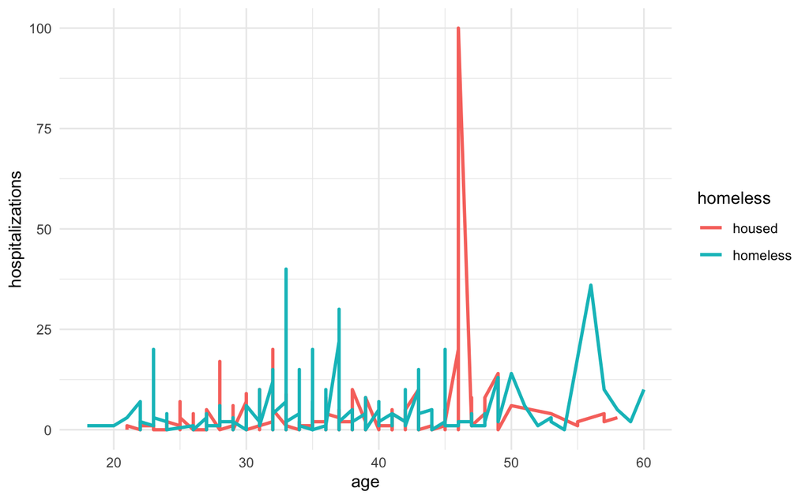

```r
library(esquisse)
ggplot(HELPmiss) +
 aes(x = age, y = hospitalizations, colour = homeless) +
 geom_line(size = 1L) +
 scale_color_hue() +
 theme_minimal()
```